# Actividad 1.8 Análisis Factorial II

Raúl Correa Ocañas

2024-08-25

# Importacion

```r
dataset = read.csv("../data/cars93.csv")
head(dataset, 5)
```

```
##   V1 V2  V3  V4   V5   V6 V7 V8                        V9
## 1 18  8 307 130 3504 12.0 70  1 chevrolet chevelle malibu
## 2 15  8 350 165 3693 11.5 70  1         buick skylark 320
## 3 18  8 318 150 3436 11.0 70  1        plymouth satellite
## 4 16  8 304 150 3433 12.0 70  1             amc rebel sst
## 5 17  8 302 140 3449 10.5 70  1               ford torino
```

```r
dataset_limpio = na.omit(dataset)
dataset_limpio = dataset_limpio[,c(-8, -9)]
head(dataset_limpio, 5)
```

```
##   V1 V2  V3  V4   V5   V6 V7
## 1 18  8 307 130 3504 12.0 70
## 2 15  8 350 165 3693 11.5 70
## 3 18  8 318 150 3436 11.0 70
## 4 16  8 304 150 3433 12.0 70
## 5 17  8 302 140 3449 10.5 70
```

# Prueba de Normalidad Multivariada

```r
result = mvn(dataset_limpio, mvnTest = "mardia", alpha = 0.05)
result$multivariateNormality
```

```
##              Test        Statistic               p value Result
## 1 Mardia Skewness 980.306302410341 8.83518200960475e-153     NO
## 2 Mardia Kurtosis 18.0290946226721                     0     NO
## 3             MVN             <NA>                  <NA>     NO
```

```r
result$univariateNormality
```

```
##               Test  Variable Statistic   p value Normality
## 1 Anderson-Darling    V1        3.5321  <0.001      NO
## 2 Anderson-Darling    V2       42.9803  <0.001      NO
## 3 Anderson-Darling    V3       17.4240  <0.001      NO
## 4 Anderson-Darling    V4       12.6748  <0.001      NO
## 5 Anderson-Darling    V5        7.2199  <0.001      NO
## 6 Anderson-Darling    V6        0.8379  0.0306      NO
## 7 Anderson-Darling    V7        5.1878  <0.001      NO
```

La información definitivamente no corresponde a una normal multivariada. Al hace la prueba conjunta, el sesgo y curtosis de la información no corresponde a lo esperado de una Normal Multivariada. Así mismo, al hacer las pruebas univariadas, ninguna fue aceptada como una distribución normal. Por ende, se puede decir con confianza que los datos no corresponden a una normal multivariada.

# Revisión de correlación entre variables

```r
corr.test(dataset_limpio)
```

```
## Call:corr.test(x = dataset_limpio)
## Correlation matrix
##       V1    V2    V3    V4    V5    V6    V7
## V1  1.00 -0.78 -0.81 -0.78 -0.83  0.42  0.58
## V2 -0.78  1.00  0.95  0.84  0.90 -0.50 -0.35
## V3 -0.81  0.95  1.00  0.90  0.93 -0.54 -0.37
## V4 -0.78  0.84  0.90  1.00  0.86 -0.69 -0.42
## V5 -0.83  0.90  0.93  0.86  1.00 -0.42 -0.31
## V6  0.42 -0.50 -0.54 -0.69 -0.42  1.00  0.29
## V7  0.58 -0.35 -0.37 -0.42 -0.31  0.29  1.00
## Sample Size
## [1] 392
## Probability values (Entries above the diagonal are adjusted for multiple tests.)
##    V1 V2 V3 V4 V5 V6 V7
## V1  0  0  0  0  0  0  0
## V2  0  0  0  0  0  0  0
## V3  0  0  0  0  0  0  0
## V4  0  0  0  0  0  0  0
## V5  0  0  0  0  0  0  0
## V6  0  0  0  0  0  0  0
## V7  0  0  0  0  0  0  0
##
##  To see confidence intervals of the correlations, print with the short=FALSE option
```

Todas las variables pasan las prubeas de hipotesis en cuanto a la significancia de sus respectivas correlaciones, por lo que se infiere que todas las correlaciones son significativas.

```r
spher_barl = check_sphericity_bartlett(dataset_limpio)

spher_barl
```

```
## # Test of Sphericity
##
## Bartlett's test of sphericity suggests that there is sufficient significant correlation in the data for factor analysis (Chisq(21) = 3453.87, p < .001).
```

```r
# spher_barl$chisq
# spher_barl$p
# spher_barl$dof
```

Con la prueba de Bartlett, tambien se confirma que hay suficiente correlación en los datos para un análisis factorial.

```r
K = KMO(cor(dataset_limpio))
cat("El valor del estadístico es: ", K$MSA)
```

```
## El valor del estadístico es:  0.8129217
```

Los datos también son aptos para una análisis factorial segun la prueba de KMO, donde el punto crítico es de 0.5 para aceptarse. Es considerado “Meritorio”.

# Análisis de Componentes Principales

```r
pca = prcomp(dataset_limpio, scale = FALSE)
# Indicamos scale falso porque de esta forma explicamos el 97.2% de la varianza con dos componentes principales.
pca$sdev
```

```
## [1] 855.6831753  38.9155289  16.1750792   4.8215908   2.3514673   1.6902704
## [7]   0.5222997
```

```r
cumsum(pca$sdev) / sum(pca$sdev)
```

```
## [1] 0.9299293 0.9722214 0.9898000 0.9950399 0.9975954 0.9994324 1.0000000
```

```r
pca$rotation
```

```
##             PC1         PC2          PC3          PC4          PC5          PC6
## V1  0.007595907  0.01757781 -0.041950756  0.830984320 -0.551405591 -0.056806101
## V2 -0.001792575 -0.01332247 -0.007283332 -0.004347109  0.009568195 -0.015260619
## V3 -0.114338215 -0.94557522 -0.303943149  0.009079556  0.003766508  0.010752052
## V4 -0.038966097 -0.29833816  0.947596536  0.063696300  0.005032695  0.086225628
## V5 -0.992644895  0.12086598 -0.002659998  0.003535638 -0.003929406 -0.003532083
## V6  0.001352812  0.03483082 -0.076888339 -0.020887411 -0.126058392  0.988072261
## V7  0.001336899  0.02395018 -0.044131187  0.552139222  0.824569373  0.112651882
##              PC7
## V1 -0.0079659923
## V2 -0.9997114171
## V3  0.0148528455
## V4 -0.0044030783
## V5  0.0001895202
## V6 -0.0161050472
## V7  0.0037713321
```

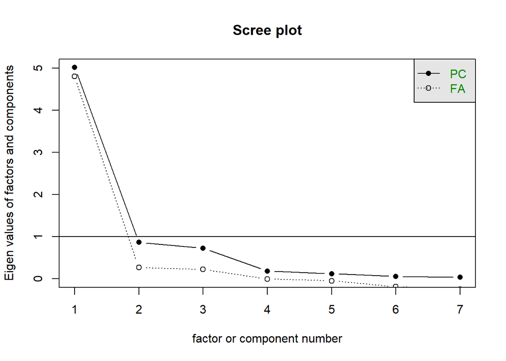

```r
scree(cor(dataset_limpio))
```

Según el gráfico, es evidente que no es necesario más de 2 componentes principales ni 2 factores para explicar la información. Más adelante se fijará la busqueda del mejor análisis factorial en 2 factores.

# Análisis Factorial

```r
fa_minres = fa(cor(dataset_limpio), nfactors = 2, rotate = "none", fm = "minres")
fa_minres_varimax = fa(cor(dataset_limpio), nfactors = 2, rotate = "varimax", fm = "minres")
fa_minres_oblimin = fa(cor(dataset_limpio), nfactors = 2, rotate = "oblimin", fm = "minres")
mr1 = data.frame(MR1_NONE = fa_minres$loadings[,1], MR1_VARIMAX = fa_minres_varimax$loadings[,1], MR1_OBLIMIN = fa_minres_oblimin$loadings[,1])

mr2 = data.frame(MR2_NONE = fa_minres$loadings[,2], MR2_VARIMAX = fa_minres_varimax$loadings[,2], MR1_OBLIMIN = fa_minres_oblimin$loadings[,2])

mr1
```

```
##      MR1_NONE MR1_VARIMAX  MR1_OBLIMIN
## V1 -0.8646381  -0.7619168 -0.727200431
## V2  0.9246023   0.9248051  0.956078190
## V3  0.9707089   0.9684852  0.999803409
## V4  0.9367441   0.9034272  0.914276025
## V5  0.9216738   0.9313099  0.968347403
## V6 -0.5593346  -0.5246863 -0.521993971
## V7 -0.5224261  -0.1930340 -0.005908754
```

```r
mr2
```

```
##        MR2_NONE MR2_VARIMAX MR1_OBLIMIN
## V1  0.139173735   0.4317999  0.27800566
## V2  0.166922903  -0.1657956  0.04369731
## V3  0.168255837  -0.1806158  0.03832672
## V4  0.072932715  -0.2581241 -0.05959793
## V5  0.193462214  -0.1398997  0.07279020
## V6 -0.001214888   0.1938064  0.08130312
## V7  0.851101523   0.9798167  0.99628505
```

```r
data.frame(NONE=fa_minres$valid, VARIMAX=fa_minres_varimax$valid, OBLIMIN=fa_minres_oblimin$valid)
```

```
##        NONE   VARIMAX   OBLIMIN
## 1 0.9730396 0.9423938 0.9758707
## 2 0.8511015 0.9798167 0.9986358
```

Según el criterio de valid de la funcion fa, el análisis factorial hecho con rotación oblimin es la que mejor discrimina las cargas entre factores. Hace sentido utilizar una rotación oblimin debido a que esperamos que los factores puedan estar correlacionados.

```r
fa_minres_oblimin$loadings
```

```
##
## Loadings:
##    MR1    MR2
## V1 -0.727  0.278
## V2  0.956
## V3  1.000
## V4  0.914
## V5  0.968
## V6 -0.522
## V7         0.996
##
##                  MR1   MR2
## SS loadings    4.489 1.089
## Proportion Var 0.641 0.156
## Cumulative Var 0.641 0.797
```

```r
fa_minres_oblimin
```

```
## Factor Analysis using method =  minres
## Call: fa(r = cor(dataset_limpio), nfactors = 2, rotate = "oblimin",
##     fm = "minres")
## Standardized loadings (pattern matrix) based upon correlation matrix
##      MR1   MR2   h2     u2 com
## V1 -0.73  0.28 0.77 0.2330 1.3
## V2  0.96  0.04 0.88 0.1172 1.0
## V3  1.00  0.04 0.97 0.0294 1.0
## V4  0.91 -0.06 0.88 0.1172 1.0
## V5  0.97  0.07 0.89 0.1131 1.0
## V6 -0.52  0.08 0.31 0.6871 1.0
## V7 -0.01  1.00 1.00 0.0027 1.0
##
##                        MR1  MR2
## SS loadings           4.55 1.15
## Proportion Var        0.65 0.16
## Cumulative Var        0.65 0.81
## Proportion Explained  0.80 0.20
## Cumulative Proportion 0.80 1.00
##
##  With factor correlations of
##      MR1  MR2
## MR1  1.0 -0.4
## MR2 -0.4  1.0
##
## Mean item complexity =  1.1
## Test of the hypothesis that 2 factors are sufficient.
##
## df null model =  21  with the objective function =  8.91
## df of  the model are 8  and the objective function was  1
##
## The root mean square of the residuals (RMSR) is  0.05
## The df corrected root mean square of the residuals is  0.08
##
## Fit based upon off diagonal values = 1
```

$V_1 - \mu= -0.727 * MR_1 + 0.278 * MR_2$

$V_2 - \mu= 0.956 * MR_1$

$V_3 - \mu= 1.000 * MR_1$

$V_4- \mu = 0.914 * MR_1$

$V_5- \mu = 0.968 * MR_1$

$V_6- \mu = -0.522 * MR_1$

$V_7- \mu = 0.996 * MR_2$

El factor 1 puede estar asociado con el rendimiento del vehiculo. Las variables V2 - V5 muestran variables que son asociadas a la potencia de un vehiculo. La variable V1, altas millas por galón, implicaría eficiencia lo cual normalmente es el caso contrario para alta potencia. Por otro lado, el factor 2 está vinculado con las variables 1 y 7, por lo cual probablemente esté explicando el avance tecnológico con los años. Esta idea se respalda con la alta carga para la variable del año del carro.

# Conclusiones